# Data Visualization with ggplot2

Eren Ada

2025-02-14

[figure not shown]

## Introduction to ggplot2

ggplot2 is a powerful package for creating beautiful visualizations in R. It’s based on the “Grammar of Graphics,” which means we build plots layer by layer. Think of it like making a sandwich:

1. First, you need a base (the data)
2. Then add your main ingredients (geometric shapes like points, lines, or bars)
3. Finally, add your toppings (colors, labels, themes)

Let’s start by loading the required packages and our sample data:

```r
# Load required R packages for visualization
library(tidyverse)  # Includes ggplot2 and data manipulation tools
library(viridis)    # Color-blind friendly color palettes
# Create sample gene expression dataset
gene_data <- tibble(
  gene_id = c("BRCA1", "TP53", "EGFR", "KRAS", "HER2"),        # Gene names
  control_1 = c(100, 150, 80, 200, 120),                        # Control replicate 1
  control_2 = c(110, 140, 85, 190, 125),                        # Control replicate 2
  treated_1 = c(200, 300, 90, 180, 240),                        # Treatment replicate 1
  treated_2 = c(190, 280, 95, 185, 230),                        # Treatment replicate 2
  chromosome = c("17", "17", "7", "12", "17"),                  # Chromosome location
  pathway = c("DNA repair", "Cell cycle", "Growth", "Signaling", "Growth")  # Biological pathway
)

# Convert data from wide to long format for plotting
gene_data_long <- gene_data %>%
  pivot_longer(
    cols = c(control_1, control_2, treated_1, treated_2),  # Columns to convert
    names_to = "sample",                                   # New column for sample names
    values_to = "expression"                              # New column for expression values
  )
```

## Basic ggplot2 Syntax

Every ggplot2 plot has three key components: 1. **Data**: The dataset you want to visualize 2. **Aesthetics** (`aes`): How your data maps to visual properties (x, y, color, size, etc.) 3. **Geometries** (`geom_*`): The type of plot you want to create

## 1. Bar Plots

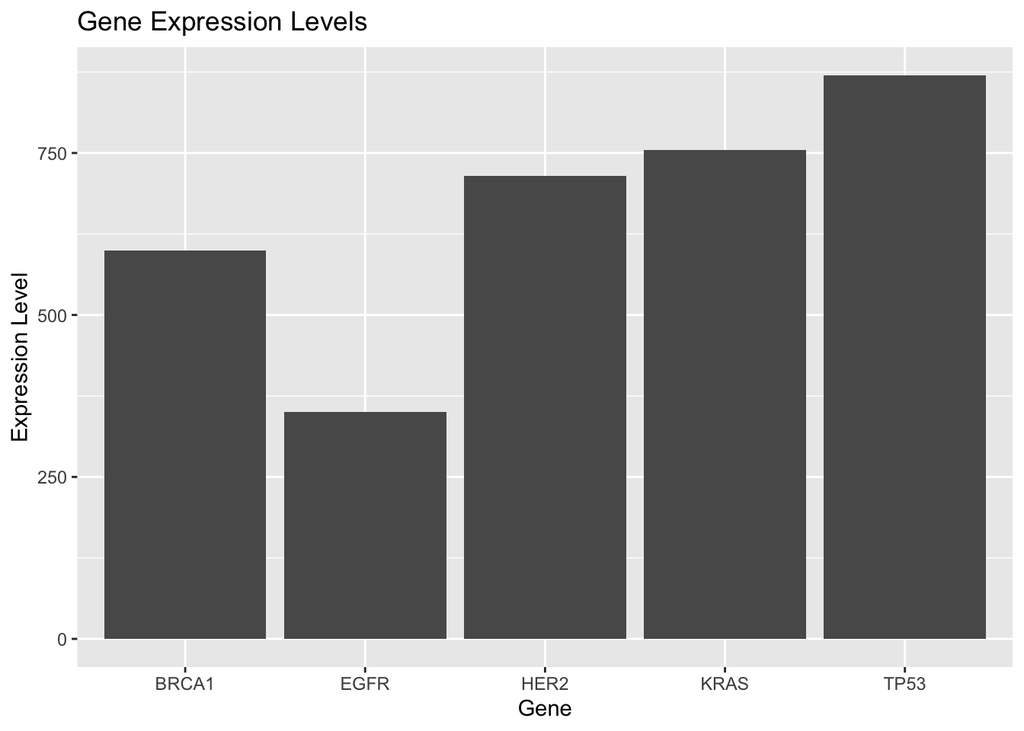

```r
# Create a simple bar plot of gene expression
ggplot(gene_data_long, aes(x = gene_id, y = expression)) +     # Map genes to x-axis, expression to y-axis
  geom_bar(stat = "identity") +                                # Create bars with heights = y values
  labs(title = "Gene Expression Levels",                       # Add plot title
       x = "Gene",                                            # Label x-axis
       y = "Expression Level")                                # Label y-axis
```

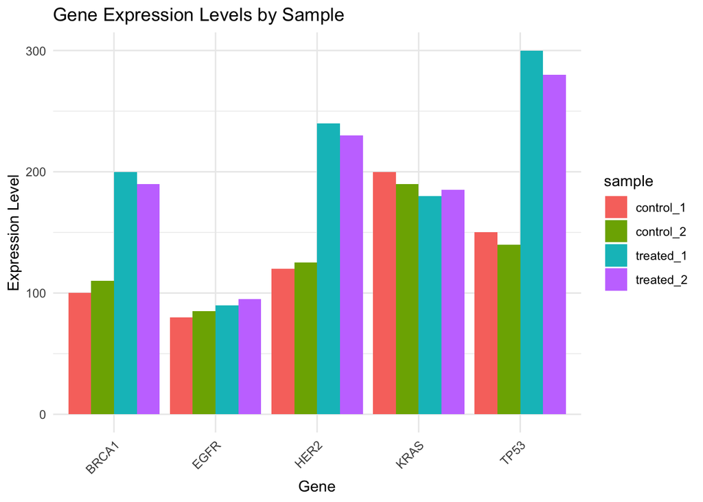

```r
# Create grouped bar plot showing expression by sample
ggplot(gene_data_long, aes(x = gene_id, y = expression, fill = sample)) +  # Add color grouping
  geom_bar(stat = "identity", position = "dodge") +           # Place bars side by side
  labs(title = "Gene Expression Levels by Sample",            # Add title
       x = "Gene",                                           # Label x-axis
       y = "Expression Level") +                             # Label y-axis
  theme_minimal() +                                          # Use minimal theme
  theme(axis.text.x = element_text(angle = 45, hjust = 1))  # Rotate x-axis labels for readability
```

## 2. Box Plots

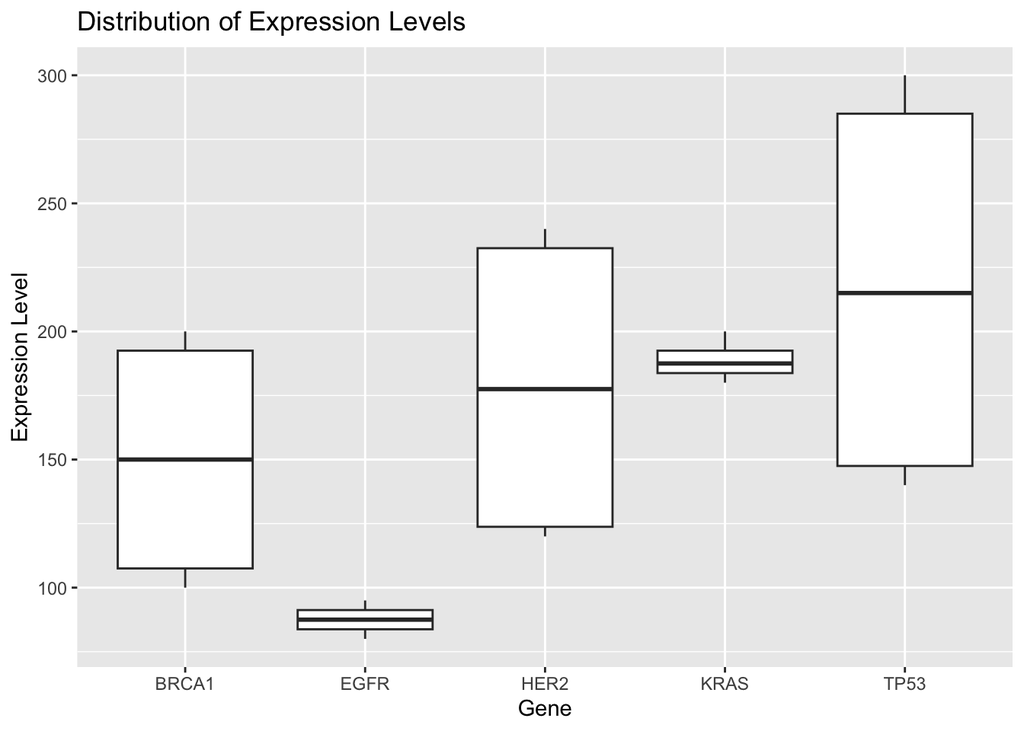

```r
# Calculate summary statistics for each gene
gene_summary <- gene_data_long %>%
  group_by(gene_id) %>%                                      # Group data by gene
  summarise(
    mean_expr = mean(expression),                           # Calculate mean expression
    sd_expr = sd(expression),                               # Calculate standard deviation
    sem_expr = sd(expression) / sqrt(n())                   # Calculate standard error
  )

# Create basic box plot
ggplot(gene_data_long, aes(x = gene_id, y = expression)) +  # Map genes to x-axis, expression to y-axis
  geom_boxplot() +                                          # Create box plot
  labs(title = "Distribution of Expression Levels",          # Add title
       x = "Gene",                                         # Label x-axis
       y = "Expression Level")                             # Label y-axis
```

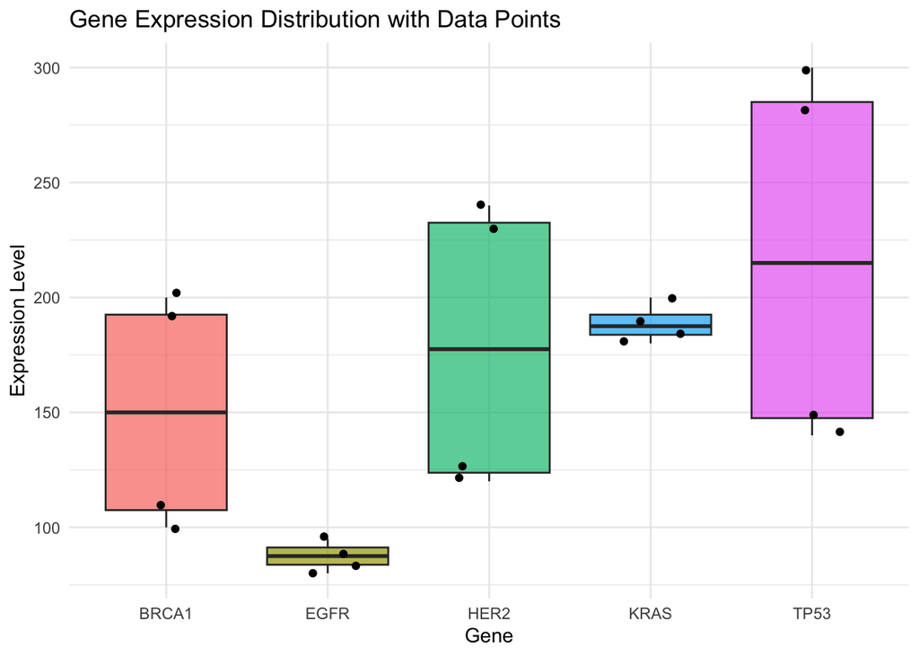

```r
# Create enhanced box plot with points
ggplot(gene_data_long, aes(x = gene_id, y = expression, fill = gene_id)) +  # Add color by gene
  geom_boxplot(alpha = 0.7) +                              # Create semi-transparent boxes
  geom_point(position = position_jitter(width = 0.2)) +    # Add jittered data points
  labs(title = "Gene Expression Distribution with Data Points",  # Add title
       x = "Gene",                                         # Label x-axis
       y = "Expression Level") +                           # Label y-axis
  theme_minimal() +                                        # Use minimal theme
  theme(legend.position = "none")                         # Remove redundant legend
```

## 3. Scatter Plots

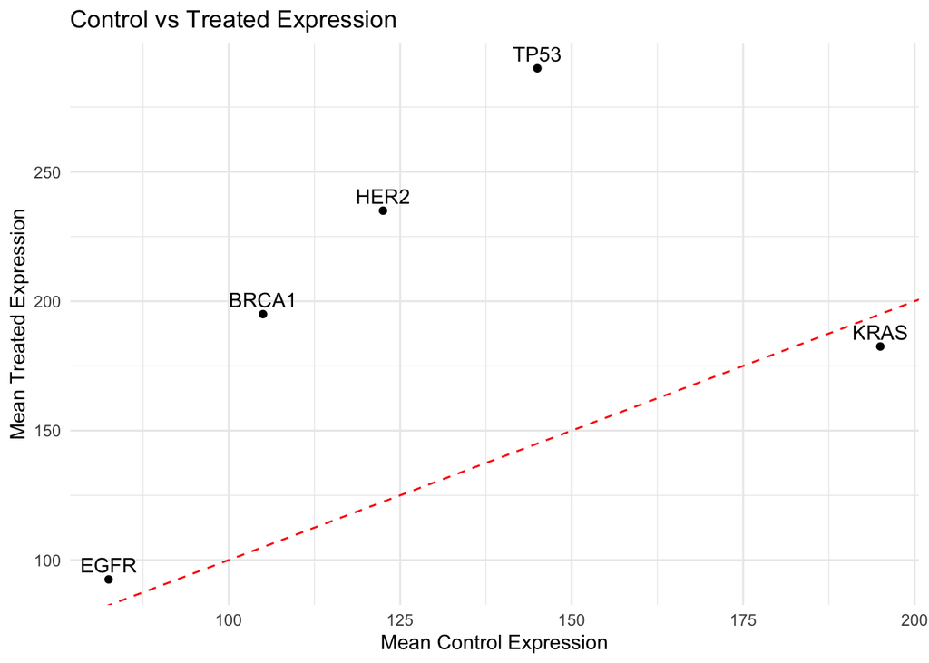

```r
# Calculate mean expression values for control and treated conditions
expression_means <- gene_data %>%
  mutate(
    mean_control = (control_1 + control_2) / 2,             # Average control replicates
    mean_treated = (treated_1 + treated_2) / 2              # Average treated replicates
  )

# Create basic scatter plot
ggplot(expression_means,
       aes(x = mean_control, y = mean_treated, label = gene_id)) +  # Map control vs treated
  geom_point() +                                            # Add points
  geom_text(vjust = -0.5) +                                # Add gene labels above points
  geom_abline(intercept = 0, slope = 1,                    # Add y=x reference line
              linetype = "dashed", color = "red") +
  labs(title = "Control vs Treated Expression",             # Add title
       x = "Mean Control Expression",                      # Label x-axis
       y = "Mean Treated Expression") +                    # Label y-axis
  theme_minimal()                                          # Use minimal theme
```

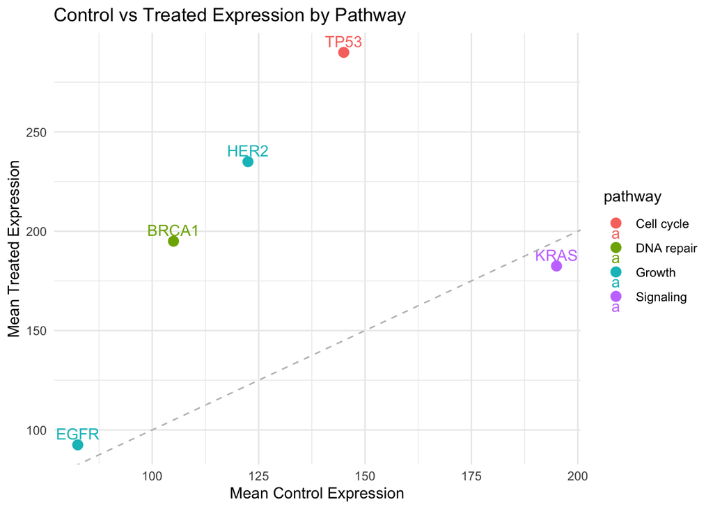

```r
# Create enhanced scatter plot with pathway information
ggplot(expression_means,
       aes(x = mean_control, y = mean_treated,
           color = pathway, label = gene_id)) +             # Color points by pathway
  geom_point(size = 3) +                                   # Add larger points
  geom_text(vjust = -0.5) +                               # Add gene labels
  geom_abline(intercept = 0, slope = 1,                   # Add reference line
              linetype = "dashed", color = "gray") +
  labs(title = "Control vs Treated Expression by Pathway",  # Add title
       x = "Mean Control Expression",                     # Label x-axis
       y = "Mean Treated Expression") +                   # Label y-axis
  theme_minimal()                                         # Use minimal theme
```

## 4. Histograms

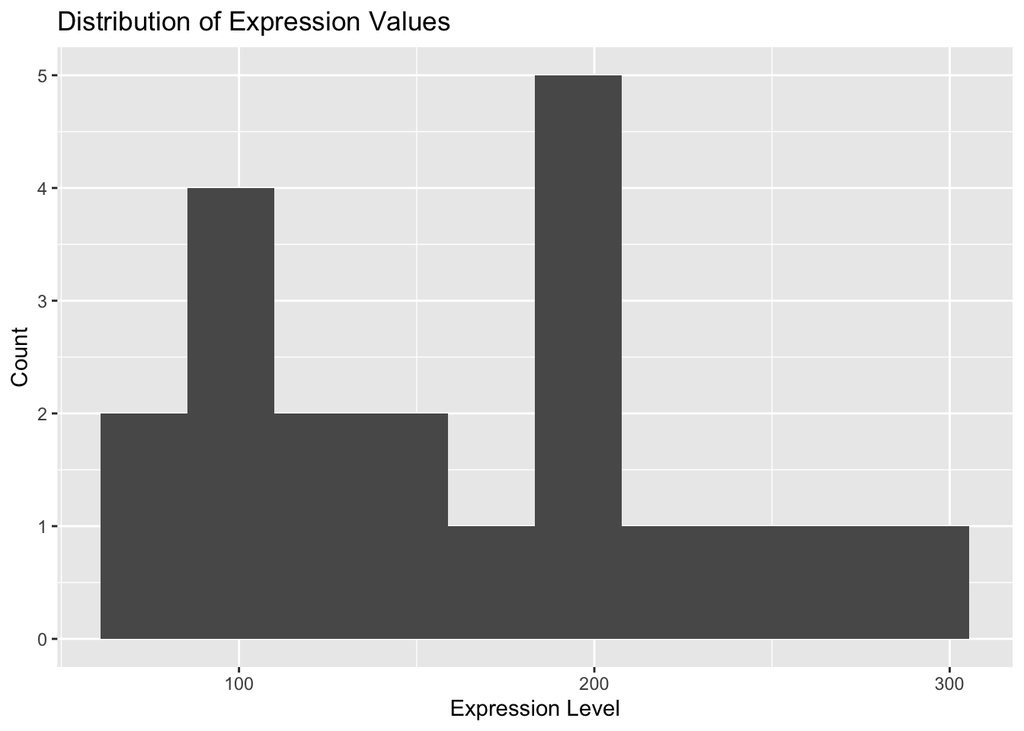

```r
# Create basic histogram of expression values
ggplot(gene_data_long, aes(x = expression)) +              # Map expression to x-axis
  geom_histogram(bins = 10) +                              # Create histogram with 10 bins
  labs(title = "Distribution of Expression Values",         # Add title
       x = "Expression Level",                            # Label x-axis
       y = "Count")                                      # Label y-axis
```

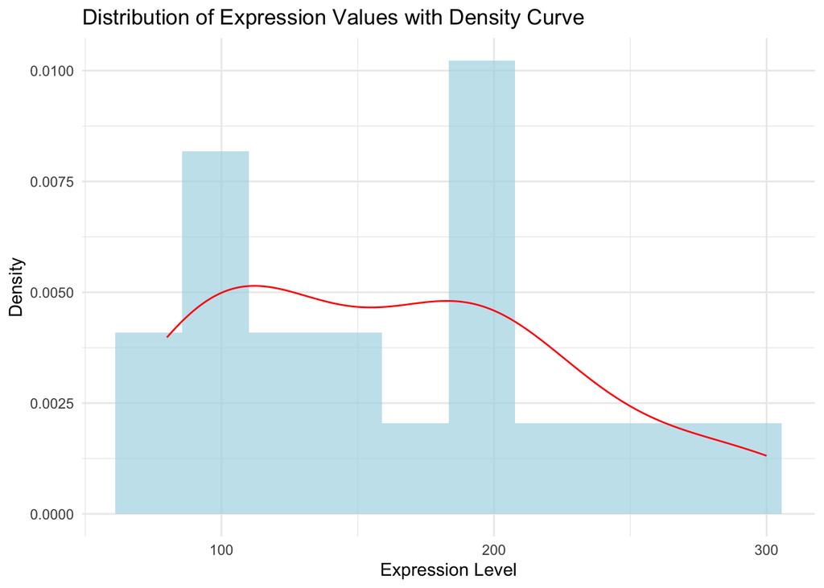

```r
# Create histogram with density curve
ggplot(gene_data_long, aes(x = expression)) +
  geom_histogram(aes(y = ..density..),                    # Show density instead of count
                 bins = 10, fill = "lightblue",
                 alpha = 0.7) +                           # Semi-transparent bars
  geom_density(color = "red") +                          # Add density curve
  labs(title = "Distribution of Expression Values with Density Curve",
       x = "Expression Level",
       y = "Density") +
  theme_minimal()
```

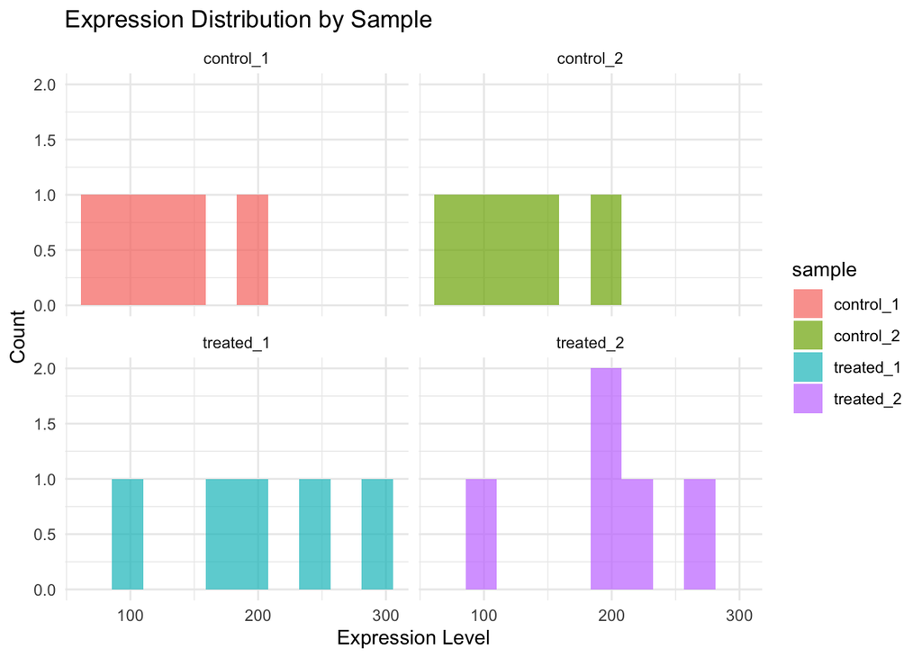

```r
# Create faceted histograms by sample
ggplot(gene_data_long, aes(x = expression, fill = sample)) +  # Color by sample
  geom_histogram(bins = 10, alpha = 0.7,                   # Create semi-transparent histogram
                 position = "identity") +
  facet_wrap(~sample) +                                    # Create separate plot for each sample
  labs(title = "Expression Distribution by Sample",         # Add title
       x = "Expression Level",                            # Label x-axis
       y = "Count") +                                     # Label y-axis
  theme_minimal()                                         # Use minimal theme
```

## 5. Heatmaps

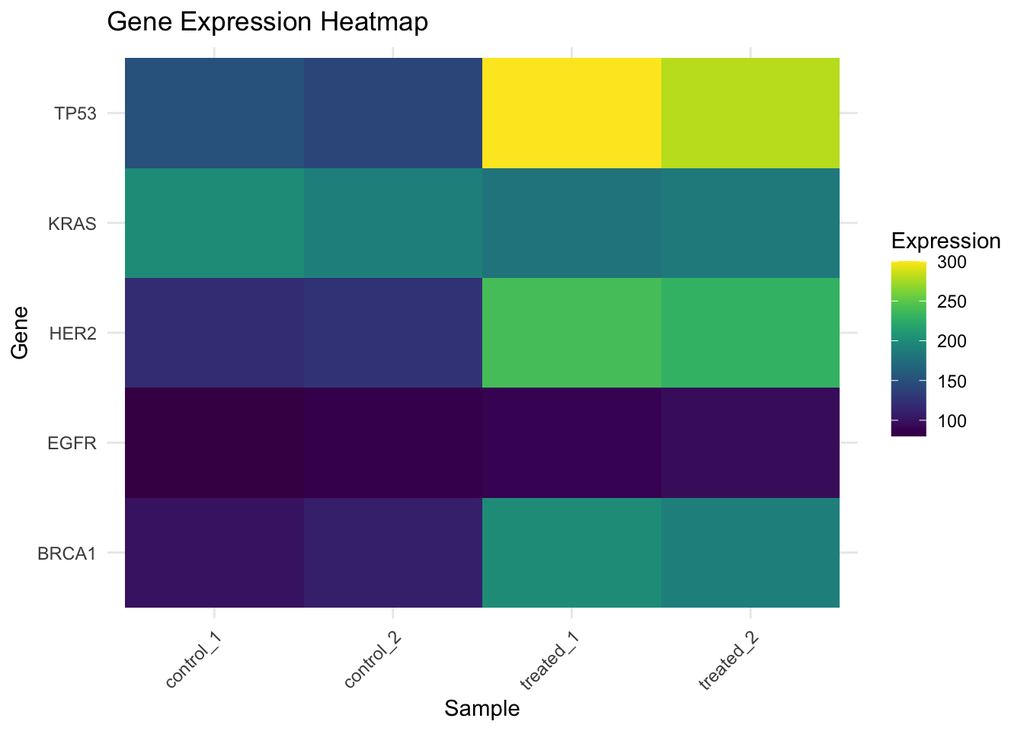

```r
# Prepare data for heatmap visualization
heatmap_data <- gene_data %>%
  select(gene_id, control_1, control_2, treated_1, treated_2) %>%  # Select relevant columns
  pivot_longer(
    cols = -gene_id,                                      # Convert to long format
    names_to = "sample",                                  # Column for sample names
    values_to = "expression"                              # Column for expression values
  )

# Create basic heatmap
ggplot(heatmap_data, aes(x = sample, y = gene_id, fill = expression)) +  # Map variables
  geom_tile() +                                           # Create tiles for heatmap
  scale_fill_viridis() +                                  # Use colorblind-friendly colors
  labs(title = "Gene Expression Heatmap",                 # Add title
       x = "Sample",                                     # Label x-axis
       y = "Gene",                                      # Label y-axis
       fill = "Expression") +                           # Label color scale
  theme_minimal() +                                      # Use minimal theme
  theme(axis.text.x = element_text(angle = 45, hjust = 1))  # Rotate x-axis labels
```

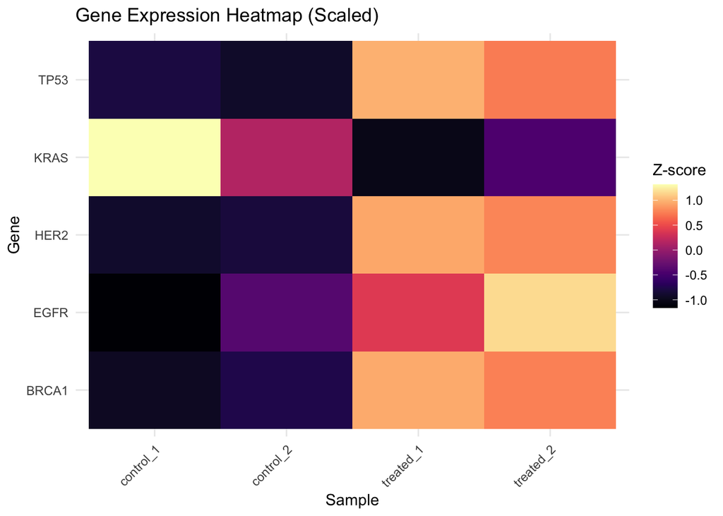

```r
# Create heatmap with Z-score normalized values
heatmap_data_scaled <- heatmap_data %>%
  group_by(gene_id) %>%                                  # Group by gene
  mutate(scaled_expression = scale(expression)[,1]) %>%  # Calculate Z-scores
  ungroup()

# Create enhanced heatmap with Z-scores
ggplot(heatmap_data_scaled,
       aes(x = sample, y = gene_id, fill = scaled_expression)) +  # Map Z-scores to color
  geom_tile() +                                          # Create tiles
  scale_fill_viridis(option = "magma") +                 # Use magma color palette
  labs(title = "Gene Expression Heatmap (Scaled)",       # Add title
       x = "Sample",                                    # Label x-axis
       y = "Gene",                                     # Label y-axis
       fill = "Z-score") +                            # Label color scale
  theme_minimal() +                                     # Use minimal theme
  theme(axis.text.x = element_text(angle = 45, hjust = 1))  # Rotate x-axis labels
```

## Customizing Plots

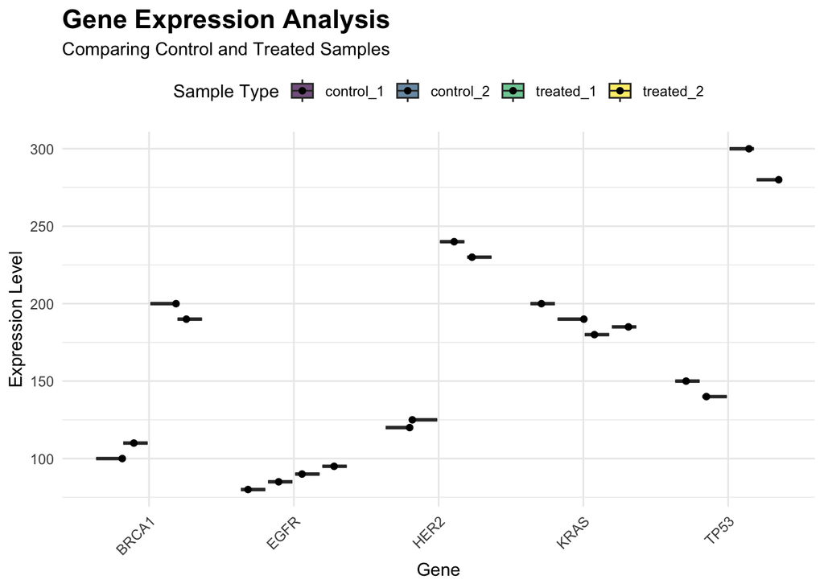

```r
# Create a highly customized plot combining multiple elements
ggplot(gene_data_long, aes(x = gene_id, y = expression, fill = sample)) +  # Map variables
  geom_boxplot(alpha = 0.7) +                            # Add semi-transparent boxplots
  geom_point(position = position_jitterdodge(            # Add jittered points
    jitter.width = 0.2)) +                               # Control point spread
  scale_fill_viridis_d() +                               # Use discrete viridis colors
  labs(
    title = "Gene Expression Analysis",                  # Main title
    subtitle = "Comparing Control and Treated Samples",   # Subtitle
    x = "Gene",                                         # x-axis label
    y = "Expression Level",                             # y-axis label
    fill = "Sample Type"                                # Legend title
  ) +
  theme_minimal() +                                      # Use minimal theme
  theme(
    plot.title = element_text(size = 16, face = "bold"), # Customize title
    axis.text.x = element_text(angle = 45, hjust = 1),   # Rotate x labels
    legend.position = "top"                              # Move legend to top
  )
```

## Common Plot Modifications

Here are some useful modifications you might want to apply to your plots:

1. **Changing Themes**:

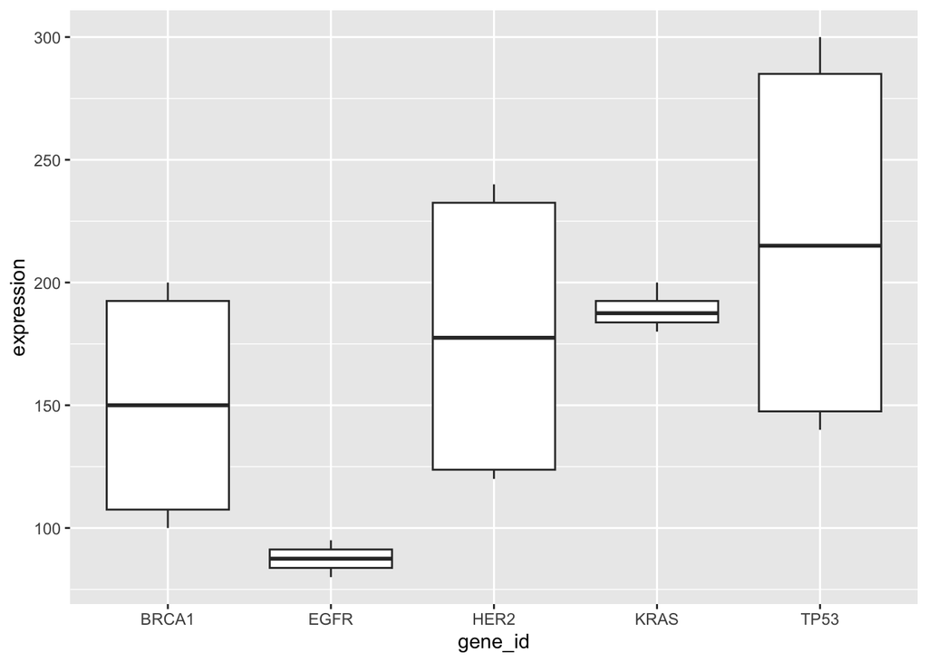

```r
# Same plot with different themes
base_plot <- ggplot(gene_data_long, aes(x = gene_id, y = expression)) +
  geom_boxplot()

# Default theme
base_plot
```

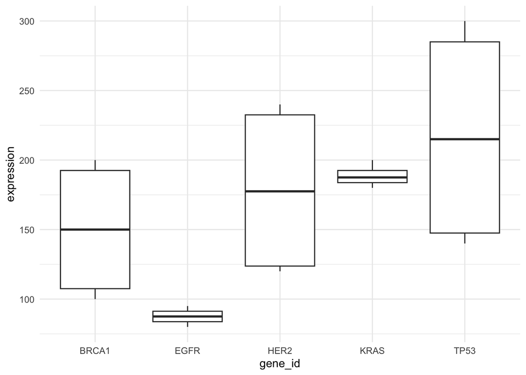

```r
# Minimal theme
base_plot + theme_minimal()
```

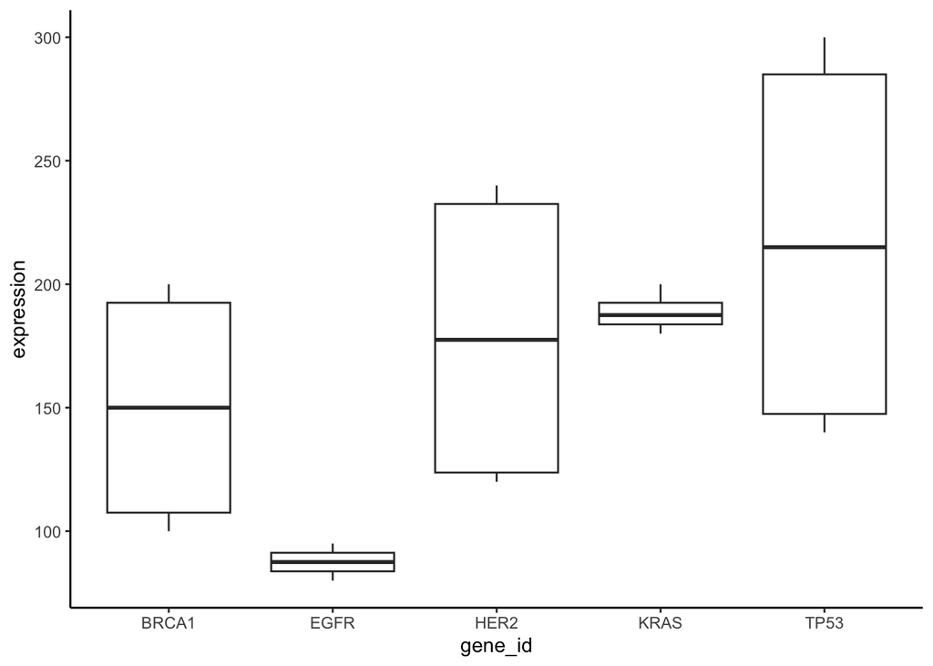

```r
# Classic theme
base_plot + theme_classic()
```

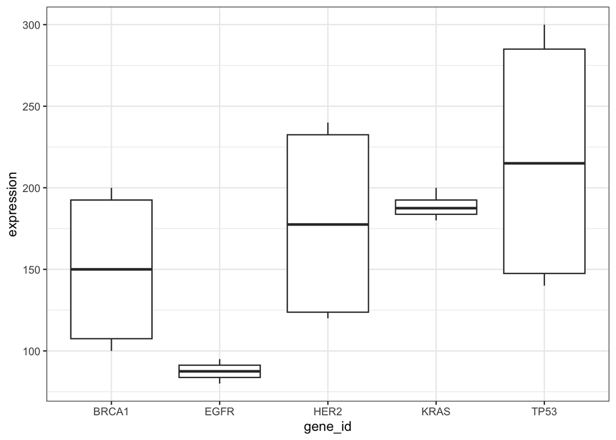

```r
# Black and white theme
base_plot + theme_bw()
```

2. **Modifying Axes**:

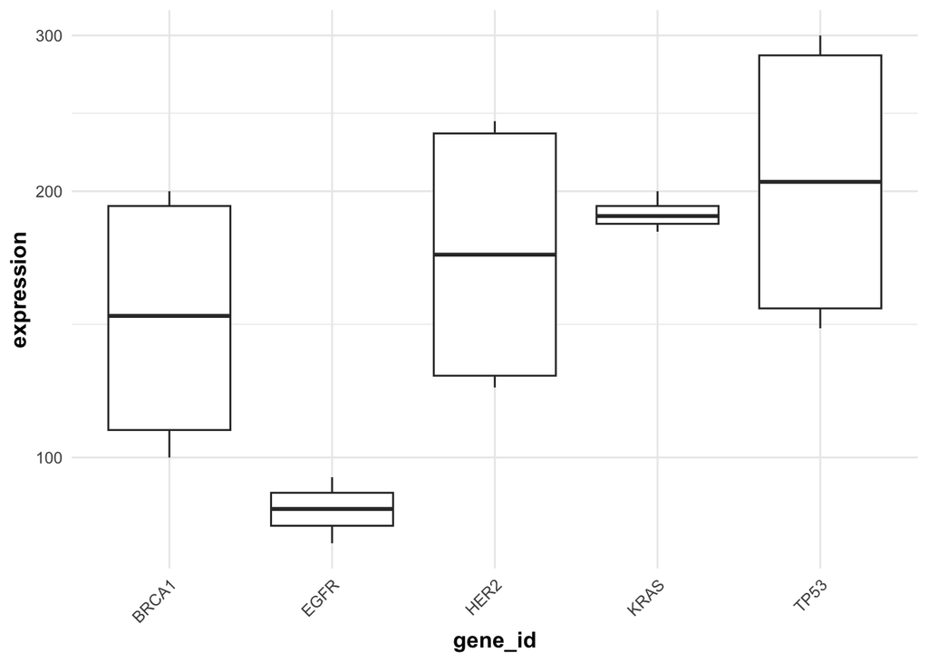

```r
base_plot +
  scale_y_log10() +  # Log scale for y-axis
  theme_minimal() +
  theme(
    axis.text.x = element_text(angle = 45, hjust = 1),  # Rotate x labels
    axis.title = element_text(size = 12, face = "bold")  # Bold axis titles
  )
```

3. **Adding Labels and Annotations**:

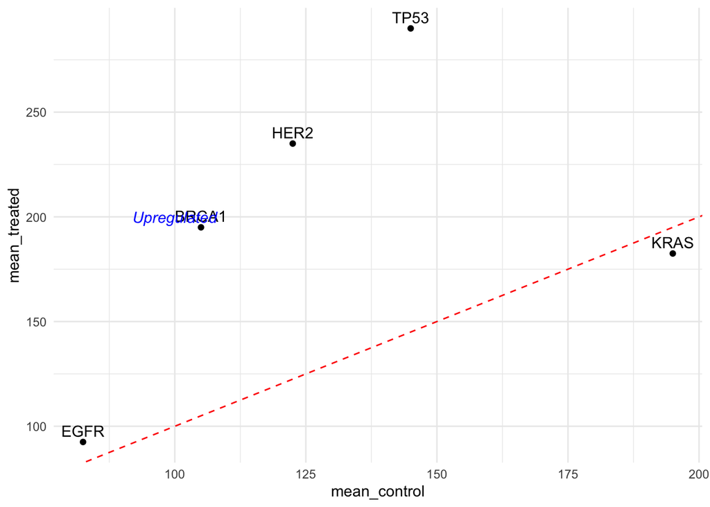

```r
ggplot(expression_means,
       aes(x = mean_control, y = mean_treated)) +
  geom_point() +
  geom_text(aes(label = gene_id), vjust = -0.5) +  # Add labels
  geom_abline(intercept = 0, slope = 1, linetype = "dashed", color = "red") +  # Add line
  annotate("text", x = 100, y = 200,
           label = "Upregulated", color = "blue", fontface = "italic") +  # Add annotation
  theme_minimal()
```